# Tugas Praktikum 5 MPDW

Sofia Lorena

2025-10-02

# Import & Subset Data

Data yang digunakan adalah 100 observasi pertama harga kopi Arabika bulanan mulai dari Januari 1960. Kolom index dihapus karena tidak relevan dengan analisis.

```r
library(rio)
data_coffee <- import("https://raw.githubusercontent.com/diazaria/mpdw/refs/heads/main/Pertemuan%201/Data%20Kelompok%205_Harga%20Kopi.xlsx")
library(dplyr)
# Buang kolom pertama pakai base R
data_coffee <- data_coffee[ , -1]


# subset baris 1 - 00
data_coffee_sub <- data_coffee[1:100, ]

# mengambil kolom ke-2 (harga kopi)
y_sub <- data_coffee_sub[[2]]

# mengambil tahun dan bulan dari baris pertama subset data
start_year  <- as.numeric(format(data_coffee_sub$`Date (Monthly)`[1], "%Y"))
start_month <- as.numeric(format(data_coffee_sub$`Date (Monthly)`[1], "%m"))

# mengubah data agar terbaca sebagai data deret waktu
data_coffee_sub.ts <- ts(y_sub,
                         start = c(start_year, start_month),
                         frequency = 12)
```

# Plot Data Time Series

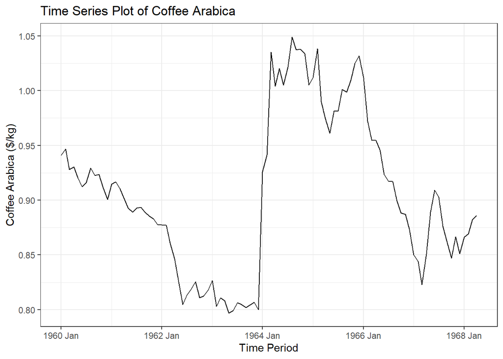

```r
library(ggplot2)
library(tsibble)
plot_coffee <- data_coffee_sub.ts |>
  as_tsibble() |>
  ggplot(aes(x = index, y = value)) +
  geom_line() +
  theme_bw() +
  xlab("Time Period") +
  ylab("Coffee Arabica ($/kg)") +
  ggtitle("Time Series Plot of Coffee Arabica")

# Tampilkan plot
plot_coffee
```

```r
# Hitung rata-rata
mean(data_coffee_sub.ts)
```

```
## [1] 0.906284
```

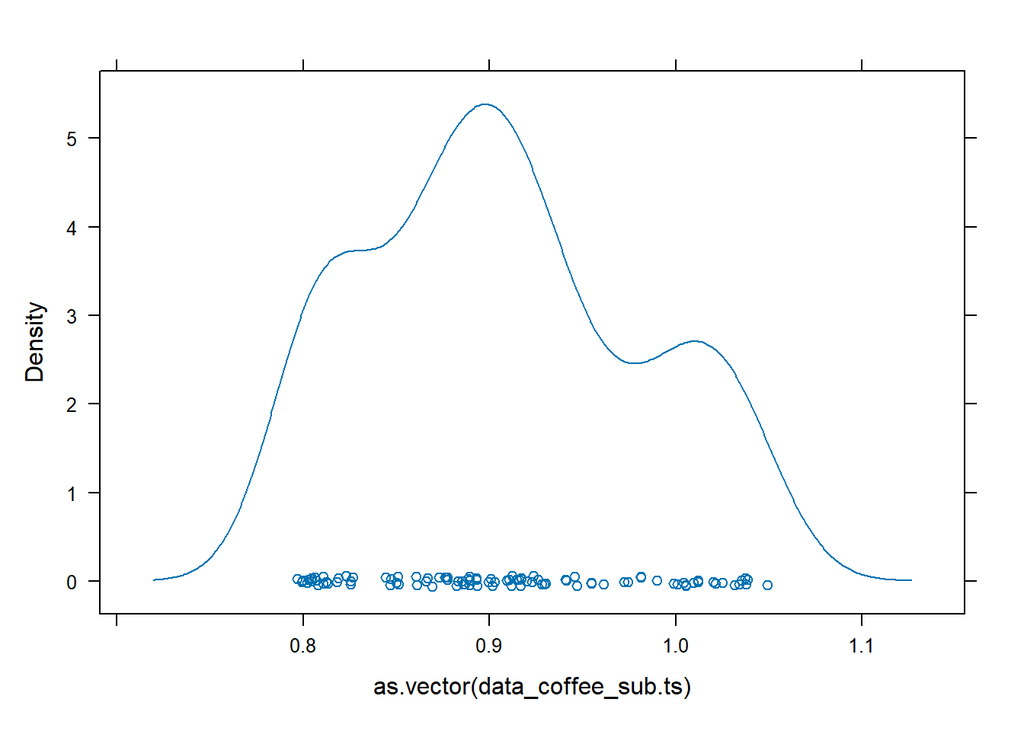

```r
lattice::densityplot(as.vector(data_coffee_sub.ts))
```

Interpretasi:

Data belum stasioner dalam rataan, karena terlihat adanya tren menurun, lalu lonjakan besar, lalu penurunan lagi. Ragam (variabilitas) juga tampak tidak stabil, karena di periode 1964–1966 fluktuasi jauh lebih besar dibanding periode awal (1960–1963). Artinya, hasil grafik sudah mendukung dugaan bahwa data butuh transformasi/differencing untuk mencapai stasioneritas.

# Plot ACF

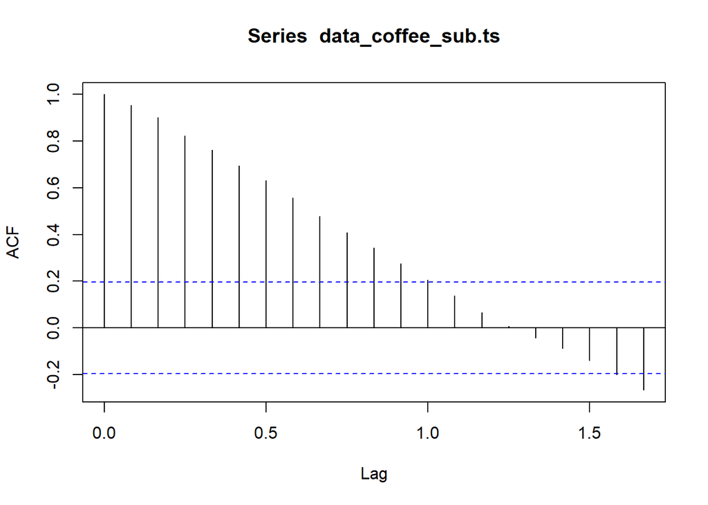

```r
acf(data_coffee_sub.ts)
```

Grafik ACF menunjukkan autokorelasi tinggi di lag awal yang menurun perlahan dan masih signifikan pada banyak lag. Pola ini menandakan adanya tren dan bahwa data belum stasioner. Oleh karena itu, perlu dilakukan transformasi seperti differencing agar data lebih sesuai untuk analisis lanjutan.

# ADF Test

```r
library(tseries)
# Uji ADF untuk data coffee
adf_result <- adf.test(data_coffee_sub.ts)

# Lihat hasil
adf_result
```

```
##
##  Augmented Dickey-Fuller Test
##
## data:  data_coffee_sub.ts
## Dickey-Fuller = -1.7537, Lag order = 4, p-value = 0.6787
## alternative hypothesis: stationary
```

Interpretasi:

Hasil Augmented Dickey-Fuller test pada data 100 observasi pertama menghasilkan nilai statistik uji sebesar -1.7537 dengan p-value 0.6787. Karena p-value lebih besar dari 0.05, maka H0 gagal ditolak. Hal ini menunjukkan bahwa data harga kopi Arabika belum stasioner dalam rataan.

# Ljung-Box Test

```r
box_test <- Box.test(data_coffee_sub.ts, lag = 12, type = "Ljung-Box")
box_test
```

```
##
##  Box-Ljung test
##
## data:  data_coffee_sub.ts
## X-squared = 511.07, df = 12, p-value < 2.2e-16
```

# Penanganan Data Tidak Stasioner

## (a) Differencing (untuk rata-rata)

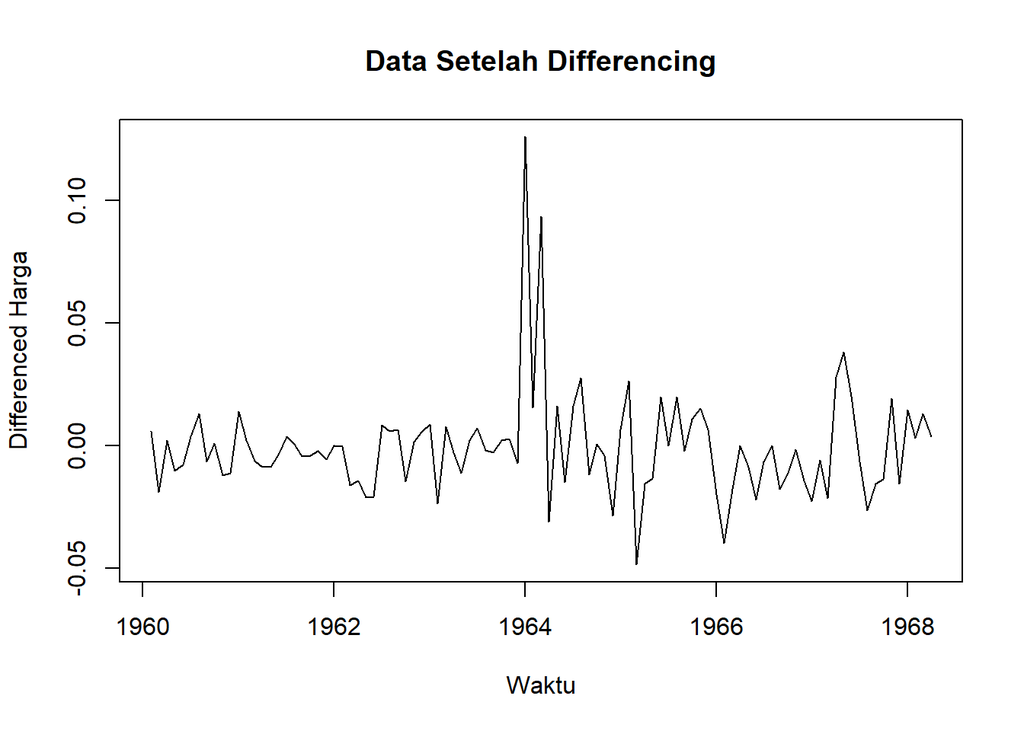

```r
# Differencing untuk rata-rata
ts_diff <- diff(data_coffee_sub.ts)

# Plot hasil differencing
plot(ts_diff, main = "Data Setelah Differencing",
     ylab = "Differenced Harga", xlab = "Waktu")
```

```r
# Uji ADF setelah differencing
adf.test(ts_diff)
```

```
##
##  Augmented Dickey-Fuller Test
##
## data:  ts_diff
## Dickey-Fuller = -3.7656, Lag order = 4, p-value = 0.02342
## alternative hypothesis: stationary
```

Interpretasi:

1. Sebelum differencing. Dari uji sebelumnya (Box-Ljung dan ADF awal), datanya tidak stasioner (ada tren / pola korelasi yang kuat).
2. Setelah differencing. Secara visual, grafik sudah lebih berfluktuasi di sekitar mean = 0. Varians terlihat relatif stabil, meskipun ada lonjakan di sekitar 1964.
3. Uji ADF. Nilai p-value = 0.02342 < 0.05, sehingga H0 (data memiliki unit root = tidak stasioner) ditolak. Artinya, setelah differencing, data sudah stasioner dalam rata-rata.

## (b) Log Transform (untuk ragam)

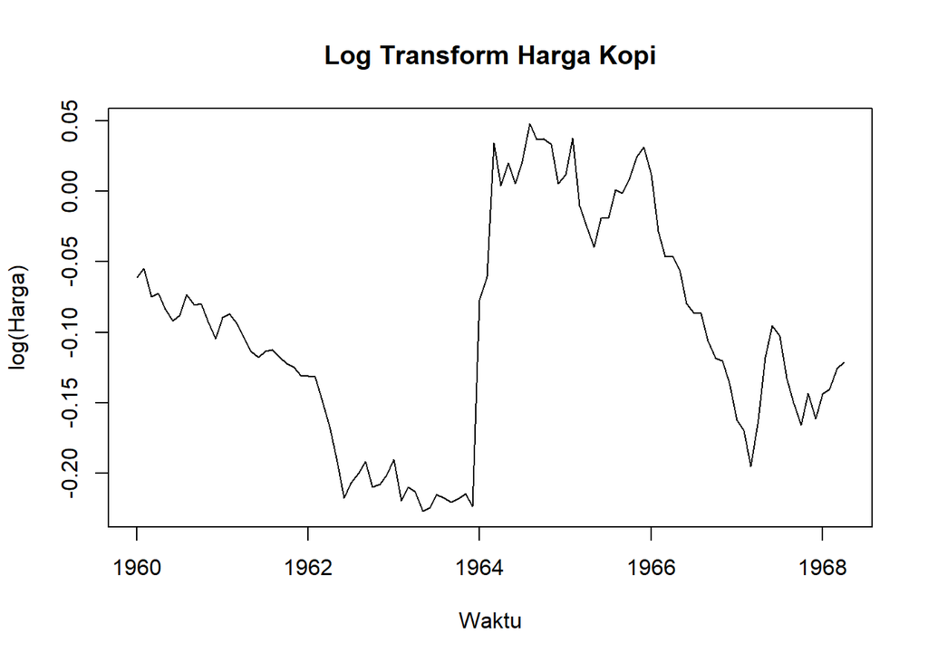

```r
ts_log <- log(data_coffee_sub.ts)
plot(ts_log, main = "Log Transform Harga Kopi",
     ylab = "log(Harga)", xlab = "Waktu")
```

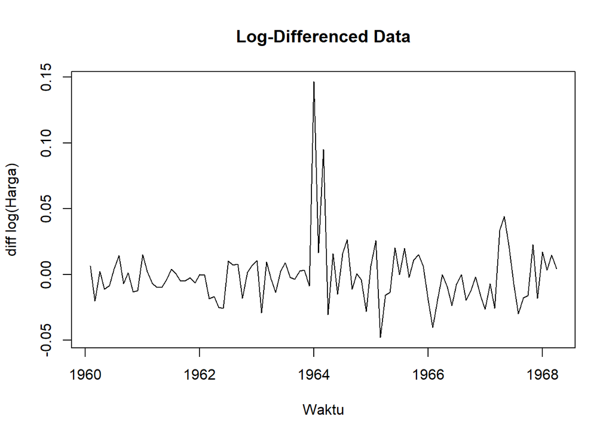

```r
# Differencing log
ts_log_diff <- diff(ts_log)
plot(ts_log_diff, main = "Log-Differenced Data",
     ylab = "diff log(Harga)", xlab = "Waktu")
```

```r
# Uji stasioneritas
adf.test(ts_log_diff)
```

```
##
##  Augmented Dickey-Fuller Test
##
## data:  ts_log_diff
## Dickey-Fuller = -3.8321, Lag order = 4, p-value = 0.02022
## alternative hypothesis: stationary
```

```r
# Uji white noise
Box.test(ts_log_diff, lag = 12, type = "Ljung-Box")
```

```
##
##  Box-Ljung test
##
## data:  ts_log_diff
## X-squared = 13.206, df = 12, p-value = 0.3543
```